## PCA Example

For our example here, we will consider a genetic example in which, given a collection of SNPs from individuals across multiple populations, we will try to determine if any one of them is responsible for some phenotypic outcome.

### SNPs

A SNP is a single-nucleotide polymorphism at a specific position in the genome. In the dataset we will be using, SNPs will be coded as {0, 1, 2}, indicating the number of minor alleles at that particular position in the chromosome. For example, a value of $0$ indicates that a position has a dominant allele in both chromosomes; a value of $1$ indicates one dominant allele and one minor allele, and a value of $2$ indicates that both positions contain the minor allele

### Dataset

The dataset is a real, consisting of 98 population-informative SNPs from 197 individuals. The individuals are made up of four groups: 50 Africans, 47 African Americans, 50 Europeans, and 50 Japanese

| Race | Freq |
| --- | --- |
| African | 50 |
| African American | 47 |
| European | 50 |
| Japanese | 50 |

While the data is real, we will simulate the penotype

$$Y = 0.5 \text{SNP}_1 + 1(\text{if J}) -1(\text{if AA}) + \epsilon$$

That is, only the first SNP will be associated with our phenotype, with higher incidence of occurence in Japanese populations and lower incidence in African American populations

## First Attempt

We can start by performing simple linear regression on each of the SNPs with the phenotype in question, plotting the log p-values benchmarked agaist an $\alpha = 0.05$ cutoff with a bonferonni correction

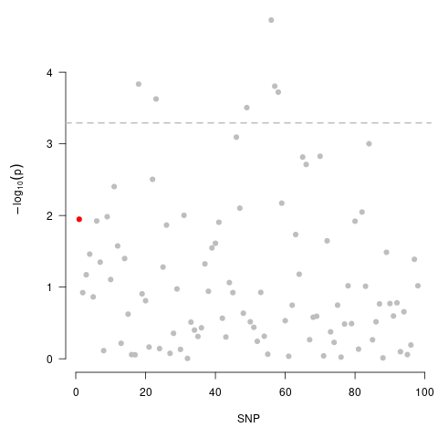

Considering only the relation of the SNPs themselves to the outcome of interest, not only did we falsely identify six SNPs, we failed to identify the single SNP actually responsible

## Principal Components

Here, we consider the `prcomp` function, returning an object of class `"prcomp"`. Of particular interest are `sdev`, `rotation`, and `x`, containing the standard deviations of the principal components, the rotation matrix, and the principal components themselves

```r
pca <- prcomp(X, scale = TRUE)
str(pca)
```

```
## List of 5
##  $ sdev    : num [1:98] 3.25 2.52 1.64 1.54 1.53 ...
##  $ rotation: num [1:98, 1:98] 0.0179 -0.0543 -0.0169 0.1852 -0.0278 ...
##   ..- attr(*, "dimnames")=List of 2
##   .. ..$ : chr [1:98] "Snp1" "Snp2" "Snp3" "Snp4" ...
##   .. ..$ : chr [1:98] "PC1" "PC2" "PC3" "PC4" ...
##  $ center  : Named num [1:98] 0.16244 0.15228 0.00508 0.30964 0.01015 ...
##   ..- attr(*, "names")= chr [1:98] "Snp1" "Snp2" "Snp3" "Snp4" ...
##  $ scale   : Named num [1:98] 0.4091 0.3602 0.0712 0.5808 0.1005 ...
##   ..- attr(*, "names")= chr [1:98] "Snp1" "Snp2" "Snp3" "Snp4" ...
##  $ x       : num [1:197, 1:98] 1.665 1.305 3.263 0.537 3.381 ...
##   ..- attr(*, "dimnames")=List of 2
##   .. ..$ : NULL
##   .. ..$ : chr [1:98] "PC1" "PC2" "PC3" "PC4" ...
##  - attr(*, "class")= chr "prcomp"
```

Recall that the PCs represent the rotated vectors of $X$, or the $U$ in

$$U = XV$$

What is especially interesting here is considering the matrix $V$ to see which components of $X$ make up the largest loadings in the first principal component (which follows from the fact that $U = XV$ implies that $UV^T = X$). Here, we identify the largest positive and negative loadings in the first PC (which will be a SNP). We can then tabulate the alleles in that SNP against race

```r
mpos <- which.max(pca$rotation[,1])
mneg <- which.min(pca$rotation[,1])

#kable(table(X[, mpos], Race))
#kable(table(X[, mneg], Race))
```

SNP 23 had the largest positive loading for the first PC

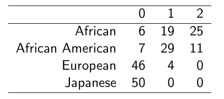

SNP 31 had the largest negative loading in the first PC

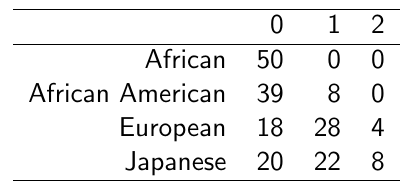

Let’s consider a similar analysis for the largest loadings associated with the second PC

```r
mpos2 <- which.max(pca$rotation[,2])
mneg2 <- which.min(pca$rotation[,2])

kable(t(table(X[, mpos2], Race)))
kable(t(table(X[, mneg2], Race)))
```

SNP 22 had the largest positive loading for the second PC

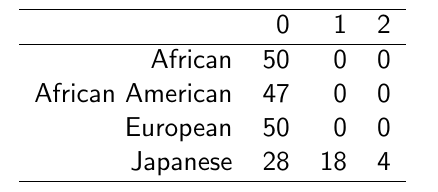

SNP 63 had the largest negative loading in the second PC

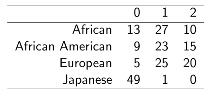

Now, let’s consider a plot of the individuals, grouped by population, against the first and second principal components

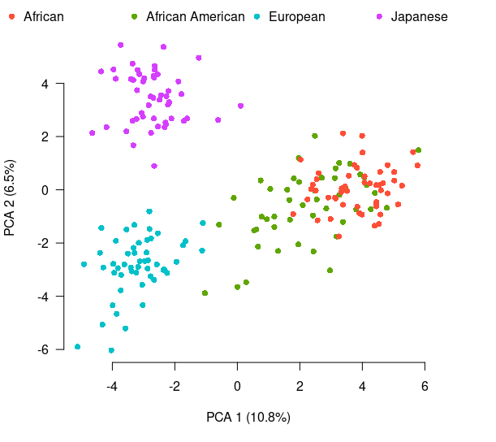

Finally, we reconsider the analysis we had done previously, still performing semi-univariate linear regression, except this time including the first two principal components as demographic “indicators”

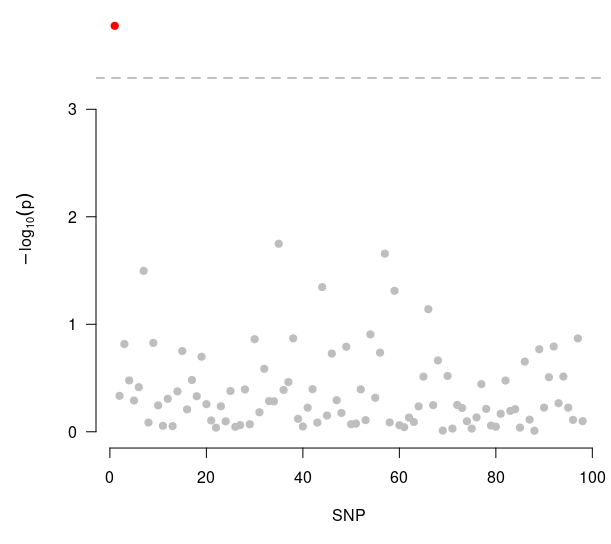